# Analysis of Tottenham’s 2023-2024 Season Performance in the Premier League So Far

Stand: 15/01/2024

[Anh Viet Ngo](https://www.kaggle.com/anhvietngo) - January 2024

Data Source: [Football Data from Transfermarkt](https://www.kaggle.com/datasets/davidcariboo/player-scores/data?select=games.csv)

Code source: [Github - Football Analysis](https://github.com/goviet2002/Football-Club-Analysis/tree/main)

# 1. Introduction

In this analysis, I will focus on analyzing **Tottenham Hotspur's performance so far in the 2023-2024 Premier League** season. At the time I posted this analysis, the 21th round just ended for Tottenham.

The Data consists of 9 CSV files that record data about football players and clubs including the data from matches that occur with them. I will use these files to extract important information about the team's performance. With the code I provide in Python, you can choose any clubs and seasons since the 2012-2023 season due to the dates available among files.

Throughout this analysis you will be able to understand the following:

> Clubs' main information: Link on Transfermarkt, Name, Stadium, Coach, Total Market Value...

> Players's information of that season (2023-2024)

> Goals and assists analysis

> Games results and position in the table

> Cards analysis and how it affects the game's result

> Analysis of players with the most contributions in the season

Use the code I provide in **Python** for analysis of any clubs you are interested in in a season between 2012 and now. I also a Power BI report for this analysis in the input (.pdf and .pbix file).

# 2. Data Wrangling

In this part, we will focus on cleaning the data by turning raw data into usable form for further analysis. This could be creating more columns in certain tables to gain more insights about the data based on existing columns like retrieving month or year from date column, Calculate total goals or getting only the data of the club and season we want to analyze, or adjusting the existing data types to a more reasonable one.

But first things first, we should import all necessary libraries and CSV files:

```python
import pandas as pd
import numpy as np
import seaborn as sns
import matplotlib.pyplot as plt
import matplotlib.ticker as ticker
import warnings

# suppress the warning message
warnings.filterwarnings('ignore')

competitions = pd.read_csv('/kaggle/input/player-scores/competitions.csv')
appearances = pd.read_csv('/kaggle/input/player-scores/appearances.csv')
club_games = pd.read_csv('/kaggle/input/player-scores/club_games.csv')
clubs = pd.read_csv('/kaggle/input/player-scores/clubs.csv')
game_events = pd.read_csv('/kaggle/input/player-scores/game_events.csv')
game_lineups = pd.read_csv('/kaggle/input/player-scores/game_lineups.csv')
games = pd.read_csv('/kaggle/input/player-scores/games.csv')
players = pd.read_csv('/kaggle/input/player-scores/players.csv')
player_values = pd.read_csv('/kaggle/input/player-scores/player_valuations.csv')

#For later comparison with other clubs
game = games
club = clubs
player_value = player_values
appearance = appearances
```

And choose the club name and season we are interested in. The name doesn't need to be the full name because we later use the .contains() function to get the full club name and id from it.

```python
club_name = "Tottenham" #The main name of your team e.g. Tottenham, Leipzig,...
season = 2023 #The season you want to analyze

#Club ID
clubs = clubs[clubs['name'].str.contains(club_name, case=False)]
club_id = clubs[clubs['name'].str.contains(club_name, case=False)]['club_id'].iat[0]

#Their Domestic League ID
league_id = clubs['domestic_competition_id'].iat[0]

#Get the country of the club
club_country = competitions[competitions['competition_id'] == league_id]['country_name'].iat[0]

print(f"Club ID: {club_id}")
print(f"League ID: {league_id}")
print(f"Country: {club_country}")
```

```
Club ID: 148
League ID: GB1
Country: England
```

Now we want to clean the appearances table and get all the appearances of players at the club by getting all the rows with players who have id of the club. It's not necessary to be in this season because we will filter when we use it later, now it can be used for players who have played for the club:

```python
appearances['date'] = pd.to_datetime(appearances['date'])
appearances['season'] = appearances['date'].apply(lambda x: f'{x.year}-{x.year + 1}' if x.month >= 8 else f'{x.year - 1}-{x.year}')
appearances['season_start_year'] = appearances['season'].str.split('-').str[0].astype(int)
appearances['season_end_year'] = appearances['season'].str.split('-').str[1].astype(int)
appearances['season_start_month_year'] = appearances['season_start_year'].apply(lambda x: f"08 {x}")

print(appearances[['player_id', 'player_club_id', 'player_name', 'season', 'season_start_year', 'season_end_year']].head())
```

```
   player_id  player_club_id       player_name     season  season_start_year  \
0      38004             853  Aurélien Joachim  2011-2012               2011
1      79232            8841    Ruslan Abyshov  2011-2012               2011
2      42792            6251       Sander Puri  2011-2012               2011
3      73333            1274   Vegar Hedenstad  2011-2012               2011
4     122011             195  Markus Henriksen  2011-2012               2011

   season_end_year
0             2012
1             2012
2             2012
3             2012
4             2012
```

Next, we want to get all the domestic games of this season by getting all the game ids occurred in that season and filter tables:

```python
#Get all domestic games in that season
games['date'] = pd.to_datetime(games['date'])
games = games[((games['home_club_id'] == club_id) | (games['away_club_id'] == club_id)) & (games['season'] == season)]
games_id = games[games['competition_id'] == league_id].sort_values(by='round')['game_id'].tolist()
domestic_game = games[games['competition_id'] == league_id].sort_values(by='date')

#Create an extra column which calculates the number of goals in a match
club_games = club_games[((club_games['club_id'] == club_id)) & (club_games['game_id'].isin(games_id))]
club_games['total_goals'] = club_games['own_goals'] + club_games['opponent_goals']
club_games['clean_sheets'] = club_games.apply(
    lambda row: 1 if (row['opponent_id'] == 148 and row['own_goals'] == 0) | (row['club_id'] == 148 and row['opponent_goals'] == 0) else 0,
    axis=1
)

game_events = game_events[(game_events['club_id'] == club_id ) & (game_events['game_id'].isin(games_id))]
game_lineups = game_lineups[(game_lineups['club_id'] == club_id ) & (game_lineups['game_id'].isin(games_id))]
```

Then we want to retrieve the following players of the season with the appearances table by getting all the names of players who have made at least one appearance in the season and filter it through the players table. Therefore players who haven't made any appearances for the club in the season will not appear in the table. We could fix this by filtering directly with the player's table by using the 'current_club_id' column, but it will only work for the current season and players who left the club in the current season will also not appear in the table, so, for scalability, I would rather use the first option because by filtering out players who haven't played any games for the club in the season won't affect our analysis.

```python
#Get all players in the season
appearances = appearances[appearances['player_club_id'] == club_id]
appearances = appearances[(appearances['game_id'].isin(games_id)) & (appearances['player_club_id'] == club_id)]
get_all_players = set(appearances['player_id'].to_list())

#Make an categorical order for the positions
order = ['Goalkeeper', 'Defender', 'Midfield', 'Attack']
players['position'] = pd.Categorical(players['position'], categories=order, ordered=True)
players['date_of_birth'] = pd.to_datetime(players['date_of_birth'])
players['is_foreigner'] = np.where(players['country_of_citizenship'] != club_country, 1, 0)
players['age'] = season - players['date_of_birth'].dt.year

player_values['date'] = pd.to_datetime(player_values['date'])
player_values['month_year'] = player_values['date'].apply(lambda x: f"08 {x.year}" if x >= pd.Timestamp(x.year, 7, 1) else f"08 {x.year-1}")
player_values['season'] = player_values['date'].apply(lambda x: f"{x.year}-{x.year+1}" if x >= pd.Timestamp(x.year, 7, 1) else f"{x.year-1}-{x.year}")
player_values = player_values.loc[player_values.groupby(['player_id','season'])['date'].idxmin()] #Get value only at start of season

players_current_season = players[players['player_id'].isin(get_all_players)]
players_current_season['season_start'] = f'08 {season}'

#Get the value of the following season
players_current_season = players_current_season.merge(player_values[['player_id', 'market_value_in_eur', 'month_year']],
                left_on=['season_start', 'player_id'], right_on=['month_year', 'player_id'])
attribute = ['name', 'country_of_citizenship', 'date_of_birth', 'sub_position', 'foot', 'height_in_cm', 'market_value_in_eur_y'] #Attribute for the display the players

print(players.dtypes)
```

```
player_id                                        int64
first_name                                      object
last_name                                       object
name                                            object
last_season                                      int64
current_club_id                                  int64
player_code                                     object
country_of_birth                                object
city_of_birth                                   object
country_of_citizenship                          object
date_of_birth                           datetime64[ns]
sub_position                                    object
position                                      category
foot                                            object
height_in_cm                                   float64
contract_expiration_date                        object
agent_name                                      object
image_url                                       object
url                                             object
current_club_domestic_competition_id            object
current_club_name                               object
market_value_in_eur                            float64
highest_market_value_in_eur                    float64
is_foreigner                                     int64
age                                            float64
dtype: object
```

# 3. Club's Information

Through these lines of codes, we can get the basic information about the clubs, which can be used later:

```python
'''Name, Stadium and attendance'''
name = clubs['name'].iat[0]
stadium = clubs['stadium_name'].iat[0]
attendance = clubs['stadium_seats'].iat[0]
print(f'{name} plays in {stadium} with {attendance} seats\n')

'''Club link on transfermarkt'''
url = clubs[clubs['name'].str.contains(club_name)]['url'].iat[0]
print(f"Club URL on Transfermarkt: {url}\n")

'''Coach'''
a = set(club_games[club_games['club_id'] == club_id]['own_manager_name'].tolist())
b = set(club_games[club_games['opponent_id'] == club_id]['opponent_manager_name'].tolist())
coach = list(set(a|b))
if len(coach) == 1:
    coach = coach[0]
print(f'Manager in {season}/{season+1} season is {coach}\n')

'''Total market value'''
total_market_value = players_current_season['market_value_in_eur_y'].sum()
print(f'In {season}/{season+1} the club has a total market value of {total_market_value}€\n')

'''Most valuable player'''
mvp = players_current_season[attribute][players_current_season['market_value_in_eur_y'] == players_current_season['market_value_in_eur_y'].max()]
print(f"Most valuable player of the team:\n{mvp}\n")

'''Average Age, oldest, youngest players'''
avg_age = players_current_season['age'].mean()
print(f'Average age of the team is {round(avg_age, 2)} years old\n')

oldest = players_current_season[['name', 'age']][players_current_season['age'] == players_current_season['age'].max()]
youngest = players_current_season[['name', 'age']][players_current_season['age'] == players_current_season['age'].min()]
print(f"The youngest player of the team are:\n {youngest}\n")
print(f"The oldest player of the team are:\n {oldest}")

'''most played'''
most_minutes = appearances.groupby('player_name')['minutes_played'].sum().sort_values(ascending=False).head(1)
print(f"\nPlayer with the most minutes\n {most_minutes}")
```

```
Tottenham Hotspur Football Club plays in Tottenham Hotspur Stadium with 62850 seats

Club URL on Transfermarkt: https://www.transfermarkt.co.uk/tottenham-hotspur/startseite/verein/148

Manager in 2023/2024 season is Ange Postecoglou

In 2023/2024 the club has a total market value of 764000000€

Most valuable player of the team:
             name country_of_citizenship date_of_birth        sub_position  \
6  James Maddison                England    1996-11-23  Attacking Midfield

    foot  height_in_cm  market_value_in_eur_y
6  right         175.0               70000000

Average age of the team is 24.96 years old

The youngest player of the team are:
            name   age
24  Alejo Véliz  20.0

The oldest player of the team are:
             name   age
0  Heung-min Son  31.0

Player with the most minutes
 player_name
Guglielmo Vicario    1890
Name: minutes_played, dtype: int64
```

The market value ranking and the most used XI too:

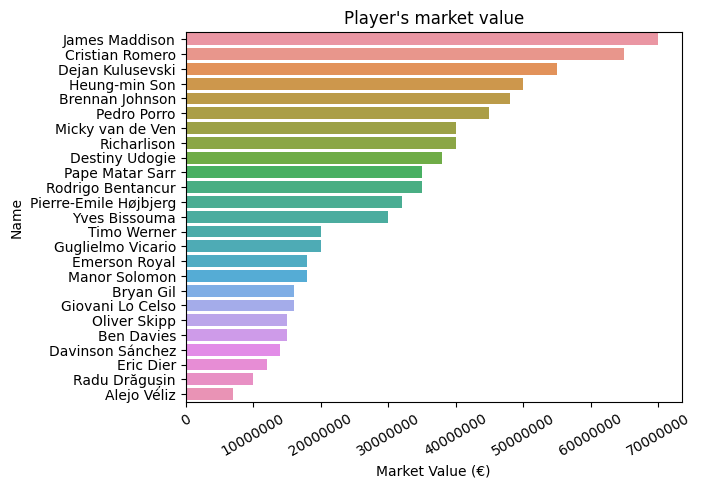

```
The most used XI of the season:
                  name country_of_citizenship date_of_birth      sub_position  \
5   Guglielmo Vicario                  Italy    1996-10-07        Goalkeeper
10    Cristian Romero              Argentina    1998-04-27       Centre-Back
19        Pedro Porro                  Spain    1999-09-13        Right-Back
20     Destiny Udogie                  Italy    2002-11-28         Left-Back
21   Micky van de Ven            Netherlands    2001-04-19       Centre-Back
14      Yves Bissouma                   Mali    1996-08-30  Central Midfield
23    Pape Matar Sarr                Senegal    2002-09-14  Central Midfield
0       Heung-min Son           Korea, South    1992-07-08       Left Winger
11        Richarlison                 Brazil    1997-05-10    Centre-Forward
15   Dejan Kulusevski                 Sweden    2000-04-25      Right Winger
16    Brennan Johnson                  Wales    2001-05-23      Right Winger

     foot  height_in_cm  market_value_in_eur_y
5   right         194.0               20000000
10  right         185.0               65000000
19  right         173.0               45000000
20   left         188.0               38000000
21   left         193.0               40000000
14  right         182.0               30000000
23  right         184.0               35000000
0    both         184.0               50000000
11  right         184.0               40000000
15   left         186.0               55000000
16  right         186.0               48000000
```

```python
sns.barplot(data=players_current_season.sort_values(by='market_value_in_eur_y', ascending=False), x='market_value_in_eur_y', y='name', edgecolor="none")
def format_func(value, tick_number):
    return f'{value:.0f}'

pvl = plt.gca()
pvl.xaxis.set_major_formatter(ticker.FuncFormatter(format_func)) #This change to full display of number in x-axis

plt.xlabel('Market Value (€)')
plt.xticks(rotation=30)

plt.ylabel('Name')
plt.title("Player's market value")
plt.show()

#XI
xi_id = appearances[(appearances['game_id'].isin(games_id))].groupby('player_id')['minutes_played'].sum(). \
        sort_values(ascending = False).index[:11].tolist()
xi = players_current_season[players_current_season['player_id'].isin(xi_id)].sort_values(by='position')[attribute]

print(f"\nThe most used XI of the season:\n {xi} \n")
```

Here we can see most of the players with the highest values are used the most in the starting lineup so far in this season. There is an exception here which is James Maddison, who has the highest value in the team. The reason turns out to be his serious injury in Oktober 2023.

# 4. Goals and Assists's Analysis

Now we will take a deeper look into the goal contribution by analyzing some important aspects that affect the team performance like the number of goals in a single match, goal distribution, top scorer, and top assisters:

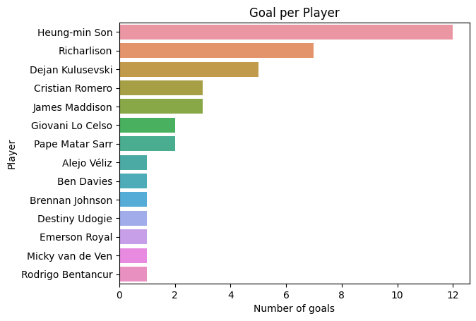

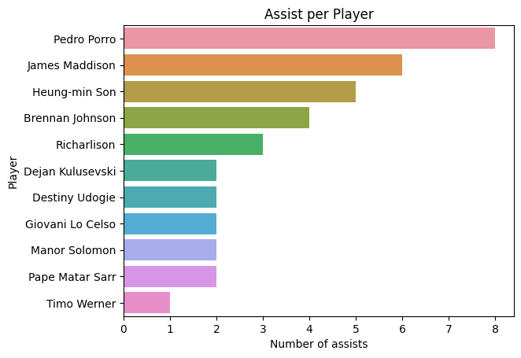

```python
#Goals per Player
goal_assist = appearances.groupby('player_name')[['goals', 'assists']].sum()
goal = goal_assist[goal_assist['goals'] > 0].sort_values(by='goals', ascending = False).reset_index()
sns.barplot(data=goal, y='player_name', x='goals')
plt.title('Goal per Player')
plt.xlabel('Number of goals')
plt.ylabel('Player')
plt.show()

#Assists per Player
assist = goal_assist[goal_assist['assists'] > 0].sort_values(by='assists', ascending = False).reset_index()
sns.barplot(data=assist, y='player_name', x='assists')
plt.title('Assist per Player')
plt.xlabel('Number of assists')
plt.ylabel('Player')
plt.show()
```

The **contribution** from goals and assists **comes mostly from our most used XI** with **Heung-min Son** as the top scorer (12 Goals) and **Pedro Porro** (8 Assists) as the top assister.

One more thing to notice that I mentioned before is the absence of **James Maddison** in the XI, although he has a substantial goal contribution for the club with already **3 Goals** and **6 Assists**. With **his return** in the squad the team's performance could be improved significantly.

Because there can sometimes be more than 1 players who have the most goal contribution, therefore players with the most goal contribution:

```python
goal_assist['total_contribution'] = goal_assist['goals'] + goal_assist['assists']
goal_assist.reset_index(inplace=True)
player_most_contribution = (goal_assist[goal_assist['total_contribution'] == goal_assist['total_contribution'].max()] \
                            [['player_name', 'total_contribution']].values.tolist())
player_most_contribution_list = [player[0] for player in player_most_contribution]

print(f"Player with the most goal contribution:")
for i in range(0, len(player_most_contribution)):
    print(f"{i+1}. {player_most_contribution[i][0]} with {player_most_contribution[i][1]} goals and assists")
```

```
Player with the most goal contribution:
1. Heung-min Son with 17 goals and assists
```

The South Korean striker and captain has had a big impact not only on the result so far, but also on motivating his teammates to play their best to bring good results for the team.

Now we want to see goal distribution in a match, which is divided into 10 buckets of 10 minutes:

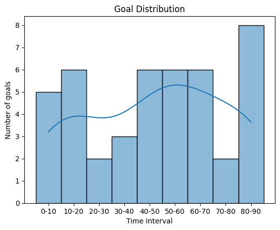

```python
bins = list(range(0, 101, 10))
label = ['0-10', '10-20', '20-30', '30-40', '40-50', '50-60', '60-70', '70-80', '80-90', '90-']
game_events['interval'] = pd.cut(game_events['minute'], bins=bins, labels=label)
total_goals = club_games['own_goals'].sum()
goals = game_events[(game_events['type'] == 'Goals') & (game_events['club_id'] == club_id)]

sns.histplot(data=goals, x='interval', kde=True)
plt.title('Goal Distribution')
plt.ylabel('Number of goals')
plt.xlabel('Time Interval')

plt.show()
```

The team tends to **score** goals in the **last 10 minutes** of the game and more goals in the **second half** than in the first half. It could also mean that the team is **better** at **adapting** to the game as it progresses and making strategic changes to their gameplay. Moreover, they are also likely to score in the first 20 minutes of the game.

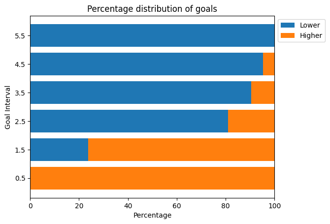

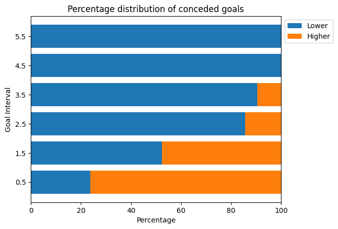

```python
goal_col = club_games['own_goals']
bins = [0.5, 1.5, 2.5, 3.5, 4.5, 5.5]
bin_labels = ['0.5', '1.5', '2.5', '3.5', '4.5', '5.5']

# Calculate percentage distribution of total goals
lower = [np.sum(goal_col < bin) / len(goal_col) * 100 for bin in bins]
higher = [np.sum(goal_col > bin) / len(goal_col) * 100 for bin in bins]

fig, plot_percentage = plt.subplots()
plot_percentage.barh(bin_labels, lower, label='Lower')
plot_percentage.barh(bin_labels, higher, left=lower, label='Higher')

plot_percentage.set_xlabel('Percentage')
plot_percentage.set_ylabel('Goal Interval')
plot_percentage.set_title('Percentage distribution of goals')
plot_percentage.legend(bbox_to_anchor=(1, 1), loc='upper left')

#Conceded Goals
conceed_col = club_games['opponent_goals']
lower = [np.sum(conceed_col < bin) / len(goal_col) * 100 for bin in bins]
higher = [np.sum(conceed_col > bin) / len(goal_col) * 100 for bin in bins]

figu, plot_percentages = plt.subplots()
plot_percentages.barh(bin_labels, lower, label='Lower')
plot_percentages.barh(bin_labels, higher, left=lower, label='Higher')

plot_percentages.set_xlabel('Percentage')
plot_percentages.set_ylabel('Goal Interval')
plot_percentages.set_title('Percentage distribution of conceded goals')
plot_percentages.legend(bbox_to_anchor=(1, 1), loc='upper left')

plt.show()
```

On the other hand, the percentage they **conceded** at least **a goal** in a match is also pretty high with nearly **80%** chance. This shows that we still need to improve our defense for better results and not drop points despite being able to score goals.

```
Tottenham has a foreign rate of 88.0%
```

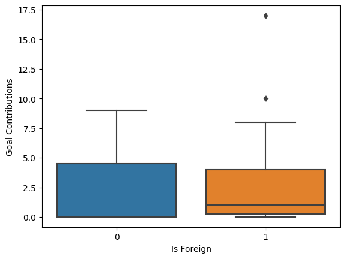

```python
'''Foreigner Rate'''
foreign_rate = players_current_season[players_current_season['is_foreigner'] == 1]['is_foreigner'].sum()/ len(players_current_season) * 100
print(f'\n{club_name} has a foreign rate of {round(foreign_rate,2)}%\n')

'''box plot of foreign players with goal contributions'''
player_contribution = players_current_season.merge(goal_assist, left_on='name', right_on='player_name', how='left')
player_contribution['total_contribution'].fillna(0, inplace=True)

sns.boxplot(data=player_contribution, x='is_foreigner', y='total_contribution')
plt.xlabel('Is Foreign')
plt.ylabel('Goal Contributions')

plt.show()
```

Tottenham has a high rate of **foreigner** in the squad and their **contribution** is in general **better** than the domestic players with an outlier of 17 goal contributions (Heung-min Son).

```python
'''points per match/ standing'''
results = {'win': 0, 'draw': 0, 'lose': 0}

# Check for wins, draws, and losses
for index, row in domestic_game.iterrows():
    if row['home_club_id'] == club_id:
        if row['home_club_goals'] > row['away_club_goals']:
            results['win'] += 1
        elif row['home_club_goals'] == row['away_club_goals']:
            results['draw'] += 1
        else:
            results['lose'] += 1
    elif row['away_club_id'] == club_id:
        if row['away_club_goals'] > row['home_club_goals']:
            results['win'] += 1
        elif row['away_club_goals'] == row['home_club_goals']:
            results['draw'] += 1
        else:
            results['lose'] += 1
print(f"Results in the season: {results}")

'''Home, Away results'''
home = {'win': 0, 'draw': 0, 'lose': 0}
for index, row in domestic_game.iterrows():
    if row['home_club_id'] == club_id:
        if row['home_club_goals'] > row['away_club_goals']:
            home['win'] += 1
        elif row['home_club_goals'] == row['away_club_goals']:
            home['draw'] += 1
        else:
            home['lose'] += 1
print(f"\nResults when playing at home: {home}")

away = {'win': 0, 'draw': 0, 'lose': 0}
for index, row in domestic_game.iterrows():
    if row['away_club_id'] == club_id:
        if row['away_club_goals'] > row['home_club_goals']:
            away['win'] += 1
        elif row['away_club_goals'] == row['home_club_goals']:
            away['draw'] += 1
        else:
            away['lose'] += 1
print(f"\nResults when playing away from home: {away}")

#Points per game
points_per_game = (results['win'] * 3 + results['draw']) / (results['win'] + results['draw'] + results['lose'])
print(f"\nAfter {results['win'] + results['draw'] + results['lose']} matches the team gets an average of {round(points_per_game, 2)} points per game")

#Clean sheets
clean_sheets = club_games['clean_sheets'].sum()
print(f'\nThe club has {clean_sheets} matches where they conceeded no goal ({round(clean_sheets/len(club_games) * 100, 2)}%)')
```

```
Results in the season: {'win': 12, 'draw': 4, 'lose': 5}

Results when playing at home: {'win': 7, 'draw': 0, 'lose': 3}

Results when playing away from home: {'win': 5, 'draw': 4, 'lose': 2}

After 21 matches the team gets an average of 1.9 points per game

The club has 5 matches where they conceeded no goal (23.81%)
```

They also have **better results** when playing **at home** with only 3 losses so far.

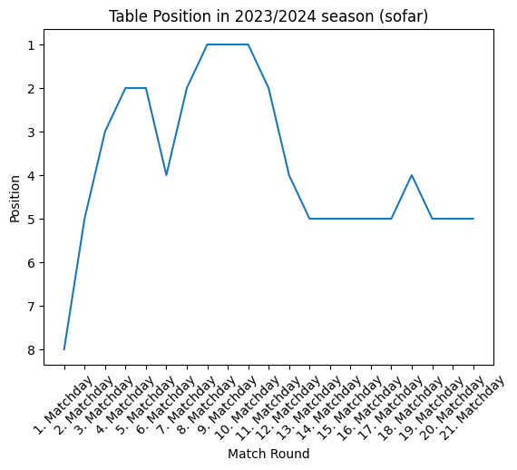

```python
position = []
round = []
for index, row in domestic_game[['round','home_club_id', 'away_club_id', 'home_club_position', 'away_club_position']].iterrows():
    round.append(row['round'])
    if row['home_club_id'] == club_id:
        position.append(row['home_club_position'])
    elif row['away_club_id'] == club_id:
        position.append(row['away_club_position'])

plt.plot(round, position)
plt.gca().invert_yaxis()
plt.title(f'Table Position in {season}/{season+1} season (sofar)')

plt.xlabel('Match Round')
plt.xticks(rotation=45)

plt.ylabel('Position')
plt.show()
```

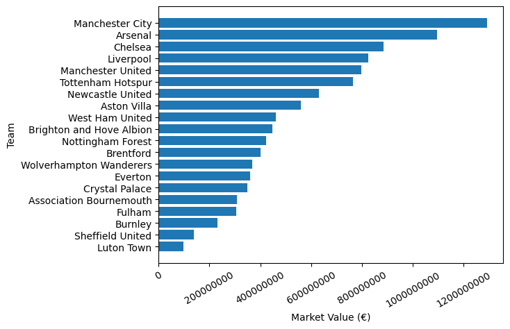

```python
clubs_id = set(game[(game['competition_id'] == league_id) & (game['season'] == season)]['home_club_id'].tolist())
team_name = []
market_value = []

for id in clubs_id: #It displays the full market value for all team in that season
    team_name.append(club[club['club_id'] == id]['name'].iat[0])

    game_team = game[((game['home_club_id'] == id) | (game['away_club_id'] == id)) & (game['season'] == season)]
    gameid = game_team[game_team['competition_id'] == league_id].sort_values(by='round')['game_id'].tolist()
    app = appearance[(appearance['game_id'].isin(gameid)) & (appearance['player_club_id'] == id)]
    get_all = set(app['player_id'].to_list())
    players_current = players[players['player_id'].isin(get_all)]
    players_current['season_start'] = f'08 {season}'
    players_current = players_current.merge(player_value[['player_id', 'market_value_in_eur', 'month_year']],
                    left_on=['season_start', 'player_id'], right_on=['month_year', 'player_id'])
    players_current.drop_duplicates(subset=['player_id'], inplace=True)

    market_value.append(players_current['market_value_in_eur_y'].sum())

team_name = [name.replace(" Football Club", "") for name in team_name] #Shorten the name but only applied for English club

#pair sort the team and their values
team_and_market_value = list(zip(team_name, market_value))
team_and_market_value.sort(key=lambda x: x[1])
team_name, market_value = zip(*team_and_market_value)

plt.barh(team_name, market_value)
ax = plt.gca()
ax.xaxis.set_major_formatter(ticker.FuncFormatter(format_func))

plt.xlabel('Market Value (€)')
plt.xticks(rotation=30)

plt.ylabel('Team')
plt.show()
```

The current position corresponds to the market value compared with other teams in the league. But there was a period when Tottenham remained in the Top 2 for a long time before falling out of the top 4 in recent rounds. The following scatter plot demonstrates my word with a tendency that **the higher the team's total market value, the higher the position** in the table.

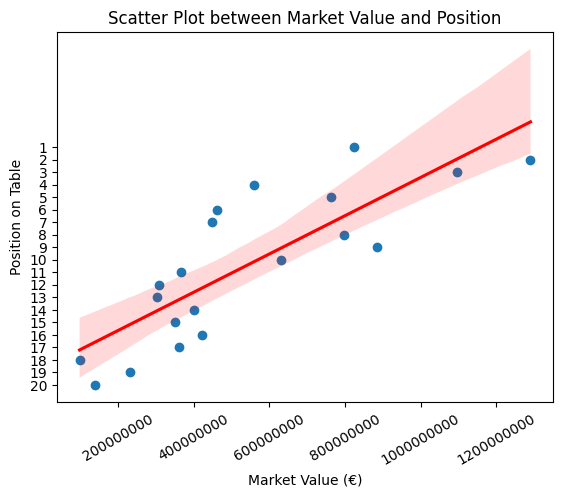

```python
#Map team name and market value to 2 lists
league = game[(game['competition_id'] == league_id) & (game['season'] == season)]
last_current_round = league.sort_values(by='date', ascending=False)['round'].iat[0]
position_home = league[league['round'] == last_current_round][['home_club_name', 'home_club_position']].values.tolist()
position_away = league[league['round'] == last_current_round][['away_club_name', 'away_club_position']].values.tolist()
league_position = position_home + position_away

# Make the club name shorter (only for English clubs)
league_position = dict([[club[0].replace(" Football Club", ""), club[1]] for club in league_position])
team_and_market_value = dict([[club[0].replace(" Football Club", ""), club[1]] for club in team_and_market_value])

get_name = list(league_position.keys())
values = [team_and_market_value[club] for club in get_name]
positions = [int(league_position[club]) for club in get_name]

plt.scatter(values, positions)
sns.regplot(x=values, y=positions, scatter=False, color='red')
plot_value_pos = plt.gca()

plt.title('Scatter Plot between Market Value and Position')
plt.xlabel('Market Value (€)')
plt.xticks(rotation=30)# This is to make the position 1 appear at the top
plot_value_pos.xaxis.set_major_formatter(ticker.FuncFormatter(format_func))

plt.ylabel('Position on Table')
plt.yticks(range(min(positions), max(positions) + 1))
plt.gca().invert_yaxis()

plt.show()
```

# 5. Cards Analysis

Cards could affect the progress and even the result of the game, especially red cards could gain the opponent human advantages.

We will see how cards affect Tottenham and who has the most cards:

```python
apps = appearances[appearances['game_id'].isin(games_id)]
total_yellow = apps[apps['game_id'].isin(games_id)]['yellow_cards'].sum()
total_red = apps[apps['game_id'].isin(games_id)]['red_cards'].sum()
print(f"The team has received {total_yellow} yellow and {total_red} red cards")
print(f"\nThe team has received average {total_yellow/ len(club_games)} yellow cards per match")
```

```
The team has received 55 yellow and 2 red cards

The team has received average 2.619047619047619 yellow cards per match
```

That is a pretty high number of cards per match. The players should play more safely and try to avoid as many cards as possible.

```python
#Player with most yellow cards
most_yellow = appearances.groupby('player_id')['yellow_cards'].sum()
no_yellow = most_yellow.max()
player_most_yellow_id = most_yellow[most_yellow == no_yellow].index.tolist()
player_most_yellow = players_current_season[attribute][players_current_season['player_id'].isin(player_most_yellow_id)]
player_most_yellow = player_most_yellow.assign(Number_of_yellow_cards=no_yellow)
print(f"Players with the most yellow cards:\n {player_most_yellow}\n")

#Player with most red cards
most_red = appearances.groupby('player_id')['red_cards'].sum().rename("sum")
no_red = most_red.max()
player_most_red_id = most_red[most_red == no_red].index.tolist()
player_most_red = players_current_season[attribute][players_current_season['player_id'].isin(player_most_red_id)]
player_most_red = player_most_red.assign(Number_of_red_cards=no_red)
print(f"Players with the most red cards:\n {player_most_red}\n")
```

```
Players with the most yellow cards:
               name country_of_citizenship date_of_birth      sub_position  \
14   Yves Bissouma                   Mali    1996-08-30  Central Midfield
20  Destiny Udogie                  Italy    2002-11-28         Left-Back

     foot  height_in_cm  market_value_in_eur_y  Number_of_yellow_cards
14  right         182.0               30000000                       7
20   left         188.0               38000000                       7

Players with the most red cards:
                name country_of_citizenship date_of_birth      sub_position  \
10  Cristian Romero              Argentina    1998-04-27       Centre-Back
14    Yves Bissouma                   Mali    1996-08-30  Central Midfield

     foot  height_in_cm  market_value_in_eur_y  Number_of_red_cards
10  right         185.0               65000000                    1
14  right         182.0               30000000                    1
```

We notice that **Yves Bissouma** is the only player who appears in **top players** with both **red** and **yellow** cards.

```python
cards = game_events[(game_events['type'] == 'Cards') & (game_events['club_id'] == club_id)]
conditions = [(cards['description'].str.contains('Yellow card', case=False)), (cards['description'].str.contains('Red|Second yellow', case=False))]
choice = ['Yellow', 'Red']
cards['card_type'] = np.select(conditions, choice)

game_id_red_card = cards[cards['description'].str.contains('Red|Second yellow', case=False)]['game_id'].tolist()
game_red = games[games['game_id'].isin(set(game_id_red_card))]
df_ids = pd.DataFrame(game_id_red_card, columns=['id'])
df_ids['Number of cards'] = df_ids.groupby('id')['id'].transform('count')
df_ids = df_ids.drop_duplicates()
game_red = game_red.merge(df_ids, left_on='game_id', right_on='id')[['season', 'round', 'date', 'home_club_name', 'aggregate', 'away_club_name', 'Number of cards']]
print(game_red)
```

```
   season         round       date                   home_club_name aggregate  \
0    2023   8. Matchday 2023-10-07         Luton Town Football Club       0:1
1    2023  11. Matchday 2023-11-06  Tottenham Hotspur Football Club       1:4
2    2023  17. Matchday 2023-12-15  Nottingham Forest Football Club       0:2

                    away_club_name  Number of cards
0  Tottenham Hotspur Football Club                1
1            Chelsea Football Club                2
2  Tottenham Hotspur Football Club                1
```

These are matches in which Tottenham received red cards. They still manage to **maintain good results after receiving a red card**. But there is also a match they even had to receive 2 red cards, which is probably really rare in a football match.

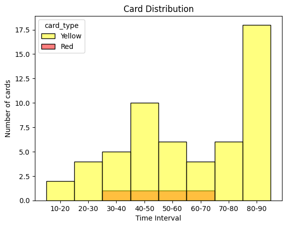

```python
if not cards.empty:
    card_hist = sns.histplot(data=cards, x='interval', hue='card_type', palette=['yellow', 'red'])
    plt.title('Card Distribution')
    plt.ylabel('Number of cards')
    plt.xlabel('Time Interval')
    plt.show()
else: pass
```

Tottenham tends to **get cards at the end of each half**, which is pretty reasonable when they try to slow their opponent down and stop counterattacks to maintain the results.

# 6. Analysis of Player with most contribution

As we found out earlier, Heung-min Son is the player with the most contribution to the club with 17 Goals + Assists. The captain has been at the club since 2015 and we are going further into his market value over time and his seasonal contribution to the clubs.

```
            name country_of_citizenship date_of_birth sub_position  foot  \
0  Heung-min Son           Korea, South    1992-07-08  Left Winger  both

   height_in_cm  market_value_in_eur_y
0         184.0               50000000
```

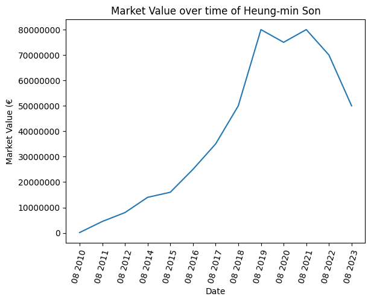

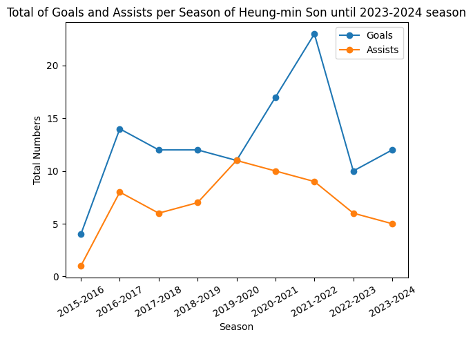

```python
for player_most_contribution_name in player_most_contribution_list: #in case there are more than 1 player
    player_most_contribution_id = players_current_season[players_current_season['name'] == player_most_contribution_name]['player_id'].iat[0]
    print(f"\n{players_current_season[players_current_season['name'] == player_most_contribution_name][attribute]}\n")

    #Market value over time until the analyzed season
    value_over_time = player_values[player_values['date'] <= f'{season+1}-06-30'] \
            .merge(players_current_season[players_current_season['name'] == player_most_contribution_name][['player_id', 'name']], on='player_id')
    sns.lineplot(data=value_over_time, x='month_year', y='market_value_in_eur')

    plt.xlabel('Date')
    plt.xticks(rotation=75)

    plt.ylabel('Market Value (€')
    value_time_plot = plt.gca()
    value_time_plot.yaxis.set_major_formatter(ticker.FuncFormatter(format_func))

    plt.title(f'Market Value over time of {player_most_contribution_name}')
    plt.show()


    #Reload apperances again to get stats of previous season
    #Get his game contributions
    his_data = appearance[(appearance['player_id'] == player_most_contribution_id)
                    & (appearance['player_club_id'] == club_id)
                    & (appearance['competition_id'] == league_id)
                    & (appearance['season_start_year'] <= season)]

    his_contributions= his_data.groupby('season').agg({
        'goals': ['sum', 'mean'],
        'assists': ['sum', 'mean'],
        'yellow_cards': ['sum', 'mean'],
        'red_cards': ['sum', 'mean'],
        'minutes_played': ['sum', 'mean']
    }).reset_index()

    for column in ['goals', 'assists', 'yellow_cards', 'red_cards', 'minutes_played']:
        his_contributions[(column, 'mean')] = his_contributions[(column, 'mean')].round(2)

    goals_sum = his_contributions[('goals', 'sum')].tolist()
    assists_sum = his_contributions[('assists', 'sum')].tolist()
    seasons = his_contributions['season'].tolist()

    # Plot goals
    plt.plot(seasons, goals_sum, marker='o', label='Goals')

    # Plot assists
    plt.plot(seasons, assists_sum, marker='o', label='Assists')

    plt.xlabel('Season')
    plt.xticks(rotation=30)

    plt.ylabel('Total Numbers')
    plt.title(f'Total of Goals and Assists per Season of {player_most_contribution_name} until {season}-{season+1} season')
    plt.legend()

    plt.show()
```

He remains one of the most important players for the club and the team should still rely on it to gain good results.

# 7. Conclusion

**Key findings:**

> Tottenham Hotspur is an offensive team that has a high scoring rate, especially in the second half and the last 10 minutes of the game.

> The team relies heavily on the goal contribution of Heung-min Son, who is the top scorer and the captain of the team.

> The team also has a high rate of foreign players, who perform better than the domestic players.

> However, the team has a weak defense, as they concede at least one goal in most of their matches. The team struggles to keep clean sheets and earn points, especially away from home.

> The team’s total market value is also correlated with their position in the table

> The team’s performance could be improved by the return of James Maddison, who is a key player in the midfield.

> Yves Bissouma is the only player who appears in top players with both red and yellow cards.

> Are still able to manage to maintain good results after receiving a red card.

> Tottenham has the tendency to get cards at the end of each half.

**Recommendations for improvements:**

> Strengthen the defense by signing or developing more reliable defenders, who can prevent the opponents from scoring and creating chances.

> Improve the team’s tactical flexibility and adaptability, by using different formations and strategies depending on the opponent and the situation of the game. This could help the team to play flexibly with the remaining players when key players become injured.

> Increase the involvement and creativity of other players, besides Heung-min Son, who can provide more goals and assists for the team.

> Manage the fitness and morale of the players, by rotating the squad and giving them enough rest and motivation.

> Try to earn as many points as possible when playing at home under huge support from home fans.

> Reduce the number of cards per match, by avoiding unnecessary fouls and respecting the referee’s decisions.

> Improve the discipline and temperament of Yves Bissouma.